# **Homework 5**

# **Permutation-based Variable Importance (PVI)**

# MIMUW XAI WINTER 2022/2023

In this homework we used brain stroke dataset from kaggle.

## Ad. 1

Calculated PVI for the model. Results below:

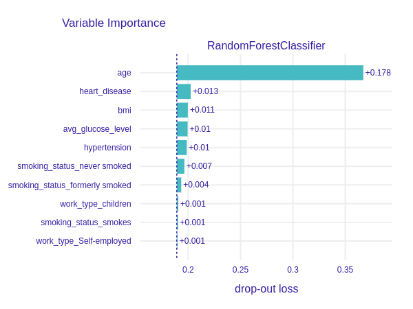

According to PVI "age" is the most important feature.

## Ad. 2

Calculated PVI on 3 different models: XGBClassifier, RandomForestClassifier with n_esitmantors=30, RandomForestClassifier with max_dept=2

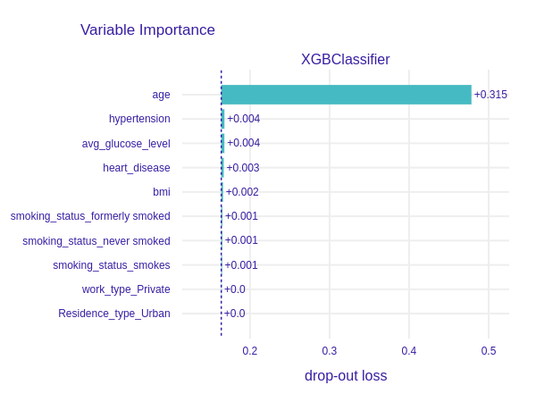

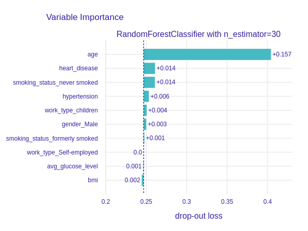

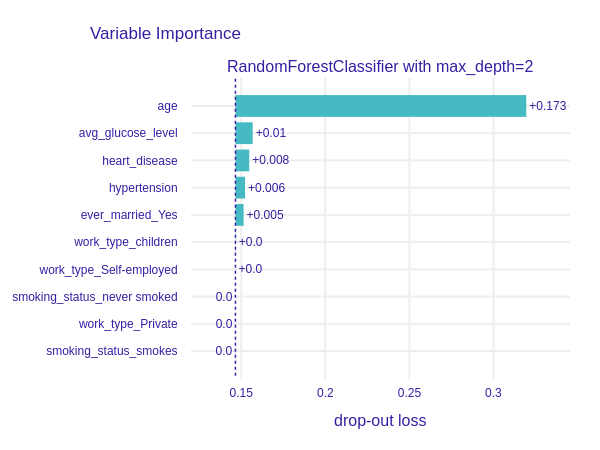

Reasults from RandomForrestClassifier are pretty similar, so changing paramateres didn't affect PVI very much. Value for "age" nearly doubled in XGBClassifier and this is probably related to architecture of XGBoost.

## Ad.3

## A) Checking gini impurity

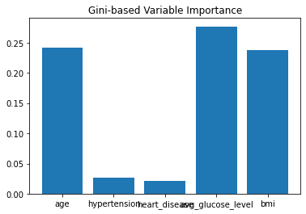

This is very surprising! avg_glucose_level have higher value than age. Also age, bmi and avg_glucose_level have similar value.

## B) Checking value importance using TreeSHAP

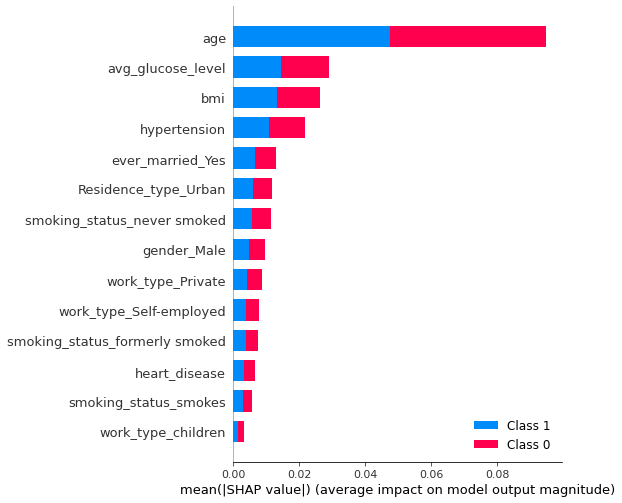

According to SHAP age is the most important as well.

## Ad.4

Unsurprisingly PVI shows "age" as the most important variable. This is although quite suspicious that "age" value is overwhelmingly big compared to other variables, especially in XGBoost model.

Order of results from SHAP is quite similar but distribution of values differ. Gini impurity gives very different results from both SHAP and PVI.

It was quite expected that these methods will differ from each other as they use different approaches.

# Appendix

## 0. Setup

```python
!pip install dalex shap catboost lime
```

```python
from sklearn.linear_model import LogisticRegression
from sklearn.preprocessing import OneHotEncoder
from sklearn.metrics import accuracy_score
from sklearn.model_selection import train_test_split
from sklearn.ensemble import RandomForestClassifier
from xgboost import XGBClassifier
import pandas as pd
import lime

import dalex as dx
import shap
```

```python
df = pd.read_csv("brain_stroke.csv")
df
```

|  | gender | age | hypertension | heart_disease | ever_married | work_type | Residence_type | avg_glucose_level | bmi | smoking_status | stroke |
| --- | --- | --- | --- | --- | --- | --- | --- | --- | --- | --- | --- |
| 0 | Male | 67.0 | 0 | 1 | Yes | Private | Urban | 228.69 | 36.6 | formerly smoked | 1 |
| 1 | Male | 80.0 | 0 | 1 | Yes | Private | Rural | 105.92 | 32.5 | never smoked | 1 |
| 2 | Female | 49.0 | 0 | 0 | Yes | Private | Urban | 171.23 | 34.4 | smokes | 1 |
| 3 | Female | 79.0 | 1 | 0 | Yes | Self-employed | Rural | 174.12 | 24.0 | never smoked | 1 |
| 4 | Male | 81.0 | 0 | 0 | Yes | Private | Urban | 186.21 | 29.0 | formerly smoked | 1 |
| ... | ... | ... | ... | ... | ... | ... | ... | ... | ... | ... | ... |
| 4976 | Male | 41.0 | 0 | 0 | No | Private | Rural | 70.15 | 29.8 | formerly smoked | 0 |
| 4977 | Male | 40.0 | 0 | 0 | Yes | Private | Urban | 191.15 | 31.1 | smokes | 0 |
| 4978 | Female | 45.0 | 1 | 0 | Yes | Govt_job | Rural | 95.02 | 31.8 | smokes | 0 |
| 4979 | Male | 40.0 | 0 | 0 | Yes | Private | Rural | 83.94 | 30.0 | smokes | 0 |
| 4980 | Female | 80.0 | 1 | 0 | Yes | Private | Urban | 83.75 | 29.1 | never smoked | 0 |

4981 rows × 11 columns

Dataset consists of features that are nonnumerical. Let's hot encode them first.

```python
from sklearn.preprocessing import OneHotEncoder
from sklearn.compose import make_column_transformer


df_one_hot = pd.get_dummies(df, drop_first = True)
df_one_hot
```

|  | age | hypertension | heart_disease | avg_glucose_level | bmi | stroke | gender_Male | ever_married_Yes | work_type_Private | work_type_Self-employed | work_type_children | Residence_type_Urban | smoking_status_formerly smoked | smoking_status_never smoked | smoking_status_smokes |
| --- | --- | --- | --- | --- | --- | --- | --- | --- | --- | --- | --- | --- | --- | --- | --- |
| 0 | 67.0 | 0 | 1 | 228.69 | 36.6 | 1 | 1 | 1 | 1 | 0 | 0 | 1 | 1 | 0 | 0 |
| 1 | 80.0 | 0 | 1 | 105.92 | 32.5 | 1 | 1 | 1 | 1 | 0 | 0 | 0 | 0 | 1 | 0 |
| 2 | 49.0 | 0 | 0 | 171.23 | 34.4 | 1 | 0 | 1 | 1 | 0 | 0 | 1 | 0 | 0 | 1 |
| 3 | 79.0 | 1 | 0 | 174.12 | 24.0 | 1 | 0 | 1 | 0 | 1 | 0 | 0 | 0 | 1 | 0 |
| 4 | 81.0 | 0 | 0 | 186.21 | 29.0 | 1 | 1 | 1 | 1 | 0 | 0 | 1 | 1 | 0 | 0 |
| ... | ... | ... | ... | ... | ... | ... | ... | ... | ... | ... | ... | ... | ... | ... | ... |
| 4976 | 41.0 | 0 | 0 | 70.15 | 29.8 | 0 | 1 | 0 | 1 | 0 | 0 | 0 | 1 | 0 | 0 |
| 4977 | 40.0 | 0 | 0 | 191.15 | 31.1 | 0 | 1 | 1 | 1 | 0 | 0 | 1 | 0 | 0 | 1 |
| 4978 | 45.0 | 1 | 0 | 95.02 | 31.8 | 0 | 0 | 1 | 0 | 0 | 0 | 0 | 0 | 0 | 1 |
| 4979 | 40.0 | 0 | 0 | 83.94 | 30.0 | 0 | 1 | 1 | 1 | 0 | 0 | 0 | 0 | 0 | 1 |
| 4980 | 80.0 | 1 | 0 | 83.75 | 29.1 | 0 | 0 | 1 | 1 | 0 | 0 | 1 | 0 | 1 | 0 |

4981 rows × 15 columns

Preparing train and test samples.

```python
X = df_one_hot.drop("stroke", axis=1)
y = df_one_hot.stroke
X_train, X_test, y_train, y_test =train_test_split( X, y, test_size=0.2, random_state=42)
```

```python
X_train
```

|  | age | hypertension | heart_disease | avg_glucose_level | bmi | gender_Male | ever_married_Yes | work_type_Private | work_type_Self-employed | work_type_children | Residence_type_Urban | smoking_status_formerly smoked | smoking_status_never smoked | smoking_status_smokes |
| --- | --- | --- | --- | --- | --- | --- | --- | --- | --- | --- | --- | --- | --- | --- |
| 1652 | 26.00 | 0 | 0 | 168.15 | 22.9 | 0 | 0 | 1 | 0 | 0 | 1 | 0 | 1 | 0 |
| 1609 | 27.00 | 0 | 0 | 80.57 | 39.8 | 0 | 1 | 1 | 0 | 0 | 1 | 0 | 0 | 1 |
| 166 | 54.00 | 0 | 0 | 87.85 | 31.1 | 1 | 1 | 0 | 0 | 0 | 0 | 0 | 0 | 1 |
| 2488 | 2.00 | 0 | 0 | 92.30 | 14.8 | 0 | 0 | 0 | 0 | 1 | 0 | 0 | 0 | 0 |
| 3337 | 69.00 | 1 | 0 | 112.69 | 33.5 | 0 | 1 | 1 | 0 | 0 | 0 | 1 | 0 | 0 |
| ... | ... | ... | ... | ... | ... | ... | ... | ... | ... | ... | ... | ... | ... | ... |
| 4426 | 54.00 | 0 | 0 | 231.54 | 29.9 | 0 | 1 | 0 | 0 | 0 | 1 | 0 | 1 | 0 |
| 466 | 38.00 | 0 | 0 | 70.92 | 41.6 | 0 | 1 | 0 | 0 | 0 | 1 | 0 | 1 | 0 |
| 3092 | 13.00 | 0 | 0 | 90.60 | 16.9 | 1 | 0 | 1 | 0 | 0 | 0 | 0 | 1 | 0 |
| 3772 | 0.48 | 0 | 0 | 118.75 | 17.4 | 0 | 0 | 0 | 0 | 1 | 0 | 0 | 0 | 0 |
| 860 | 57.00 | 0 | 0 | 128.28 | 34.2 | 0 | 1 | 0 | 1 | 0 | 0 | 0 | 1 | 0 |

3984 rows × 14 columns

### 0.1 Training RandomForestClassifier classifier model

```python
random_forest = RandomForestClassifier()
random_forest.fit(X_train, y_train)
predictions_random_forest = random_forest.predict(X_test)
random_forest_acc = accuracy_score(predictions_random_forest,y_test)
model = random_forest
random_forest_acc
```

```
0.9408224674022067
```

## 1. Calculating PVI

```python
explainer = dx.Explainer(model, X_test, y_test)
```

```python
explainer.model_performance(cutoff=y_train.mean())
```

|  | recall | precision | f1 | accuracy | auc |
| --- | --- | --- | --- | --- | --- |
| RandomForestClassifier | 0.833333 | 0.140625 | 0.240642 | 0.715145 | 0.810887 |

```python
pvi = explainer.model_parts(random_state=0)
```

```python
pvi.result
```

|  | variable | dropout_loss | label |
| --- | --- | --- | --- |
| 0 | Residence_type_Urban | 0.182149 | RandomForestClassifier |
| 1 | ever_married_Yes | 0.183177 | RandomForestClassifier |
| 2 | gender_Male | 0.184169 | RandomForestClassifier |
| 3 | work_type_Private | 0.186460 | RandomForestClassifier |
| 4 | _full_model_ | 0.189113 | RandomForestClassifier |
| 5 | work_type_Self-employed | 0.189772 | RandomForestClassifier |
| 6 | smoking_status_smokes | 0.190193 | RandomForestClassifier |
| 7 | work_type_children | 0.190528 | RandomForestClassifier |
| 8 | smoking_status_formerly smoked | 0.193355 | RandomForestClassifier |
| 9 | smoking_status_never smoked | 0.196403 | RandomForestClassifier |
| 10 | hypertension | 0.198650 | RandomForestClassifier |
| 11 | avg_glucose_level | 0.199464 | RandomForestClassifier |
| 12 | bmi | 0.199677 | RandomForestClassifier |
| 13 | heart_disease | 0.202401 | RandomForestClassifier |
| 14 | age | 0.367246 | RandomForestClassifier |
| 15 | _baseline_ | 0.499058 | RandomForestClassifier |

```python
pvi.plot(show=False).update_layout(autosize=False, width=600, height=450)
```

[interactive chart not shown]

## 2. PVI for other models

```python
xgb = XGBClassifier().fit(X_train, y_train)
explainer_xgb = dx.Explainer(xgb, X_test, y_test)
pvi_xgb = explainer_xgb.model_parts()
pvi_xgb.plot(show=False).update_layout(autosize=False, width=600, height=450)
```

[output not shown]

[interactive chart not shown]

```python
model_30_est = RandomForestClassifier(
    n_estimators=30
    ).fit(X_train, y_train)
explainer_model_30_est = dx.Explainer(model_30_est, X_test, y_test,label="RandomForestClassifier with n_estimator=30")
pvi_model_30_est= explainer_model_30_est.model_parts()
pvi_model_30_est.plot(show=False).update_layout(autosize=False, width=600, height=450)
```

[output not shown]

[interactive chart not shown]

```python
model_depth_2 = RandomForestClassifier(
    max_depth=2
).fit(X_train, y_train)
explainer_model_depth_2 = dx.Explainer(model_depth_2, X_test, y_test,label="RandomForestClassifier with max_depth=2")
pvi_model_depth_2= explainer_model_depth_2.model_parts()
pvi_model_depth_2.plot(show=False).update_layout(autosize=False, width=600, height=450)
```

[output not shown]

[output not shown]

[interactive chart not shown]

## 3.A comparing with the traditional feature importance measures for trees

### Gini-based Variable Importance

```python
pd.DataFrame({'variable': X_test.columns, 'importance': model.feature_importances_})
```

|  | variable | importance |
| --- | --- | --- |
| 0 | age | 0.241636 |
| 1 | hypertension | 0.026918 |
| 2 | heart_disease | 0.021733 |
| 3 | avg_glucose_level | 0.276912 |
| 4 | bmi | 0.237558 |
| 5 | gender_Male | 0.033306 |
| 6 | ever_married_Yes | 0.019236 |
| 7 | work_type_Private | 0.024109 |
| 8 | work_type_Self-employed | 0.019148 |
| 9 | work_type_children | 0.001134 |
| 10 | Residence_type_Urban | 0.033613 |
| 11 | smoking_status_formerly smoked | 0.020696 |
| 12 | smoking_status_never smoked | 0.025697 |
| 13 | smoking_status_smokes | 0.018304 |

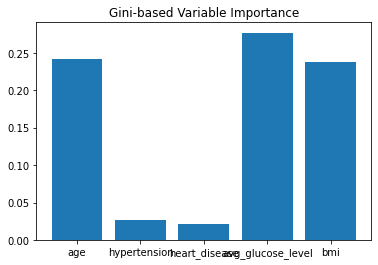

```python
import matplotlib.pyplot as plt
plt.bar(X_test.columns[:5], model.feature_importances_[:5])
plt.title("Gini-based Variable Importance")
plt.show()
```

## 3.B shap explainer

```python
shap_vi = explainer.model_parts(type="shap_wrapper", shap_explainer_type="TreeExplainer",check_additivity=False)
```

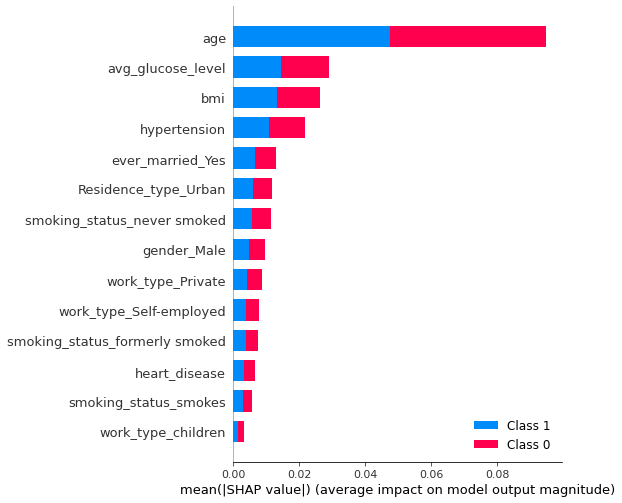

```python
shap_vi.plot()
```